# FUNDING ANALYSIS AND PROTECTION RISKS

## UNDERSTANDING THE LINK AND THE COST OF INACTION

## Global Protection Cluster

# Executive Summary

Humanitarian crises in 2025 are seeing unprecedented levels of violence, coercion, and deprivation, putting 229 million people across 18 crisis-affected countries at serious risk. Sub-national assessments show that 39% of 125,200 areas face severe to extreme protection threats.

Despite escalating needs, protection funding is falling short. In 2024, the funding gap was 51%; projections for 2025 show it may worsen, with some crises potentially seeing an 86% shortfall. This is not just a financial gap, but a systemic failure to address life-threatening risks.

GPC analysis shows that a 30–50% funding cut could affect 7.5–12.6 million people, stripping 4,400–5,000 communities of key protective services like social cohesion initiatives, and leaving up to 3.5 million without critical life-saving information.

These shortfalls weaken early warning systems, risk monitoring, legal assistance, and other vital protection services—directly increasing harm and reducing access to justice.

HNRP analysis shows that only 33% of severe and 11% of extreme protection risks are addressed under life-saving strategic objectives. Many essential interventions fall outside these frameworks.

The humanitarian system stands at a crossroads: failing to prioritize protection risks will trap millions in cycles of violence and need. Protection must be central to humanitarian efforts, guided by locally defined risk severity—not limited life-saving labels—to ensure the most urgent threats are addressed.

Key insights:

- Use local protection risk severity to guide response priorities.
- Many critical protection activities fall outside traditional life-saving classifications and risk being unfunded.
- Community-based systems for violence prevention and early warning are especially vulnerable to cuts.

The following sections visualize and explore these funding shortfalls in greater detail.

# Global Overview 2025

[interactive chart not shown]

# Overview of Protection Risks

The map below provides an overview of the combined severity of the 15 protection risks monitored by Protection Clusters, and an indication of the percentage of sub-national areas in the country where population is exposed to severe or extreme levels of violence, coercion or deliberate deprivation.

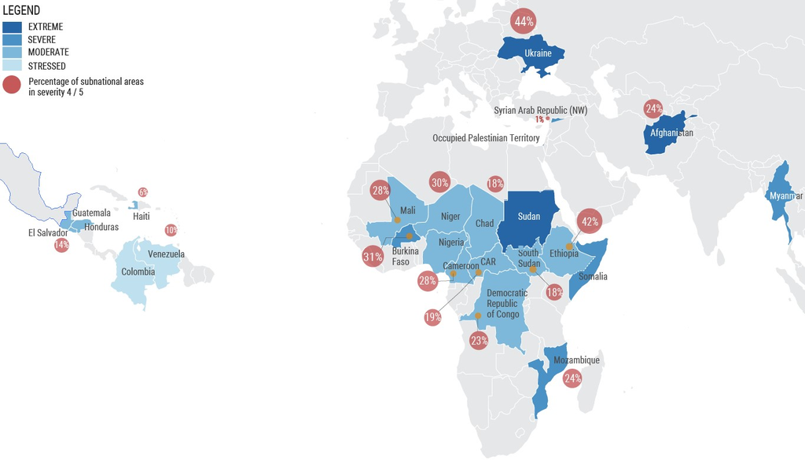

# Priority Protection Risks

The impact of today’s humanitarian crises extends beyond funding gaps to include escalating, life-threatening protection risks. As highlighted in the 2025 Global Humanitarian Overview, crises are defined by these risks, which demand urgent intervention. A 2024 assessment by Protection Clusters shows worsening conditions, with overlapping severe risks in countries like Sudan, oPt, Myanmar, Somalia, and DRC. Key risks include attacks on civilians, gender-based violence, displacement, and abductions, with country-specific threats such as mines and recruitment affecting millions. Protection Clusters continue to prioritize and report on these risks through regular Protection Analysis Updates. The chart below shows the protection risk severity (1–5) across countries and risk types.Hover to explore severity scores for each protection risk and country.

[interactive chart not shown]

# Funding Analysis - Risk & Response

## Protection Risks and Funding Gaps

In 2024, the Protection Cluster received $1.7 billion—only 49% of the $3.5 billion required—creating a 51% funding gap. Projections for 2025, based on past funding patterns and U.S. contributions, indicate an even wider average shortfall of 67% across major crises.

These cuts will severely limit protection actors’ ability to respond to urgent needs, increasing risks for millions. Though based on a limited number of countries, the GPC’s conservative analysis still provides a strong foundation for broader discussions on global protection needs.

Other countries—such as Sudan, oPt, DRC, Yemen, and Somalia—are likely facing similar challenges. The analysis underscores the urgent need for coordinated action, funding prioritization, and strategic adjustments to effectively address life-threatening protection risks.

[interactive chart not shown]

## Countries by 2025 Expected Funding Gap (%)

The map below shows the countries by Protection (expected) Funding Gap in 2025.

[interactive chart not shown]

## Comparison of subnational risk severity and funding shortfall

[interactive chart not shown]

## Projected Impact on Protection Interventions and Affected Populations

[interactive chart not shown]

Frontline humanitarian actors may face major cuts, with 2,400 to 5,400 fewer staff supported, impacting critical protection services like case management and legal aid. Community-led protection efforts could also decline, affecting up to 5,000 communities. Reduced capacity to engage on protection policies and limited access to vital information could expose 2.3 to 3.5 million people to greater risks. Though projections, the analysis of 19 countries’ HNRPs highlights serious concerns for the continuation of essential protection activities.

[interactive chart not shown]

In the 19 HNRPs analyzed, people-centred services are included in 100% of life-saving objectives. However, community-based protection appears in only 8 HNRPs (42%), advocacy in 3 HNRPs (16%), capacity strengthening in 8 HNRPs (42%), and identification, monitoring, and analysis in 9 HNRPs (47%). Only 7 HNRPs (37%) include all core protection modalities within their life-saving objectives.

[interactive chart not shown]

You can read the full report at the following link: [**GPC FUNDING ANALYSIS AND PROTECTION RISKS**](https://globalprotectioncluster.org/publications/2208/reports/report/gpc-funding-analysis-and-protection-risks-understanding-link-and)